# MSiA400_lab3_SecondPart_XiaoyunGong

Xiaoyun Gong

10/31/2021

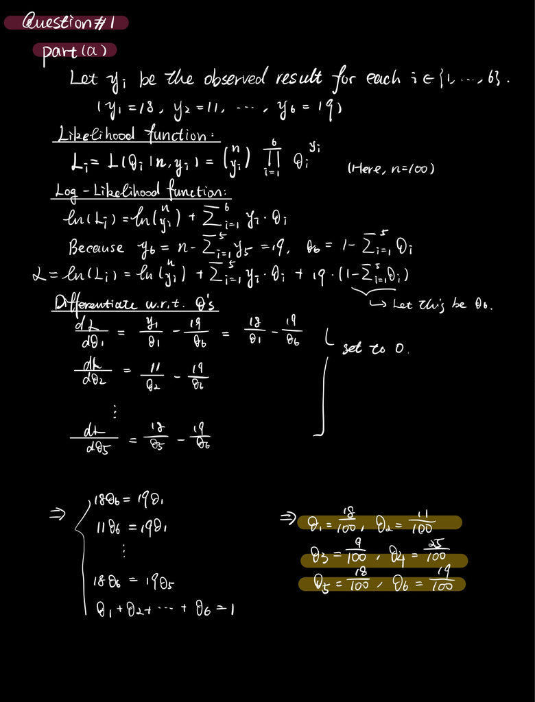

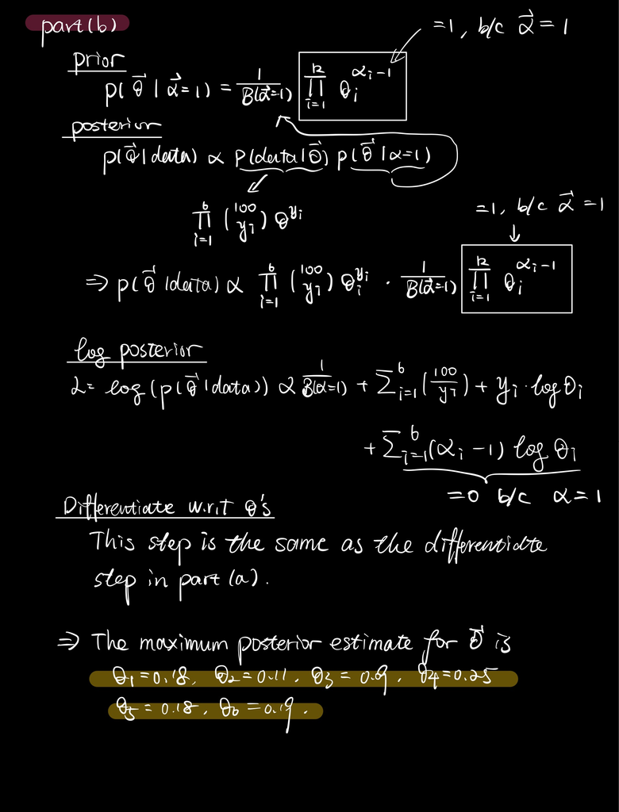

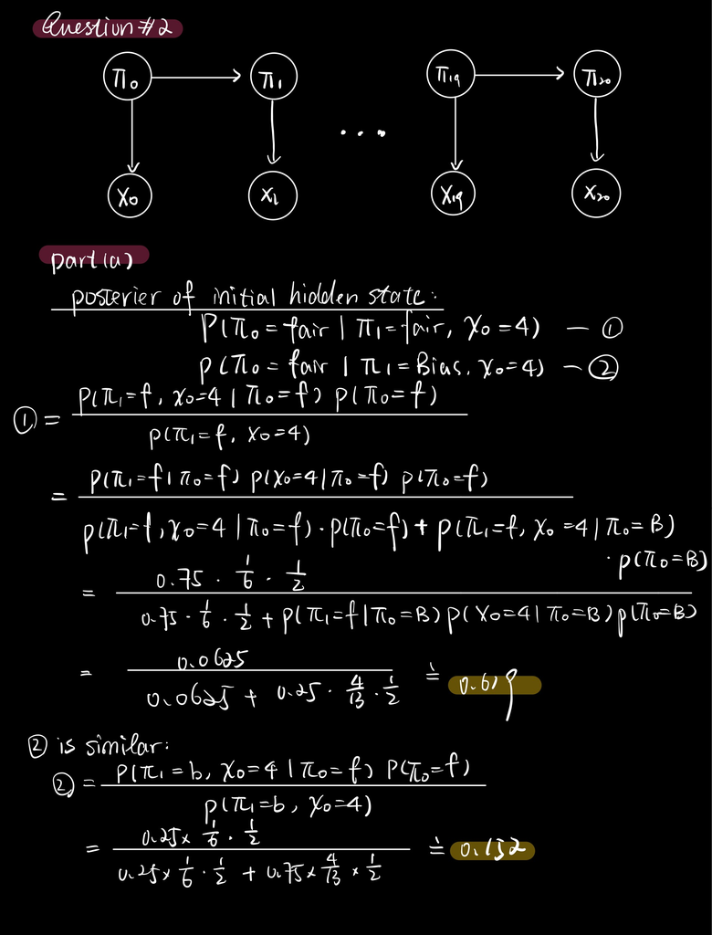

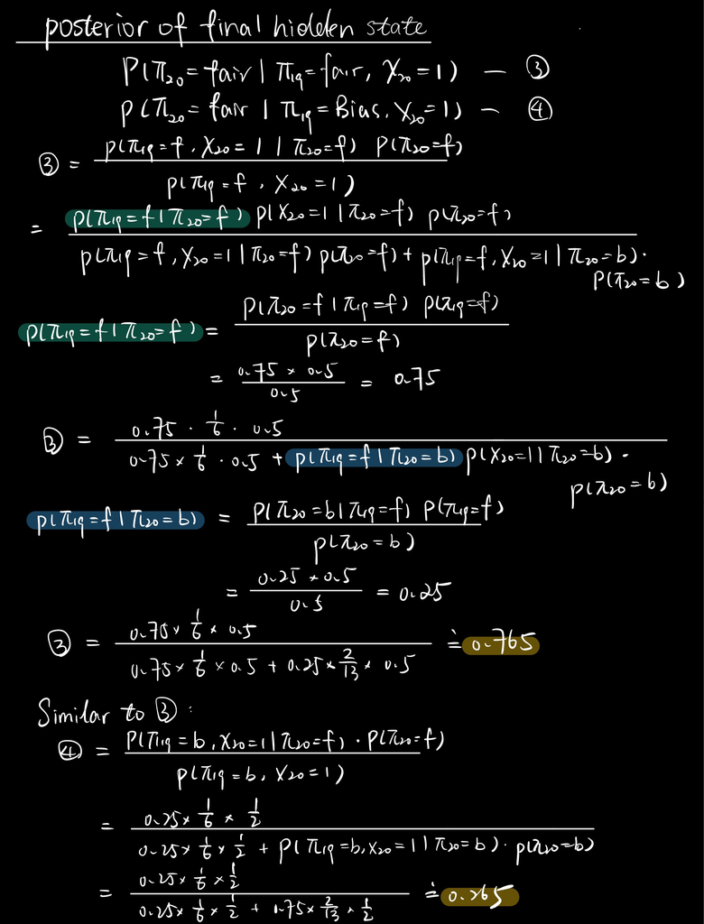

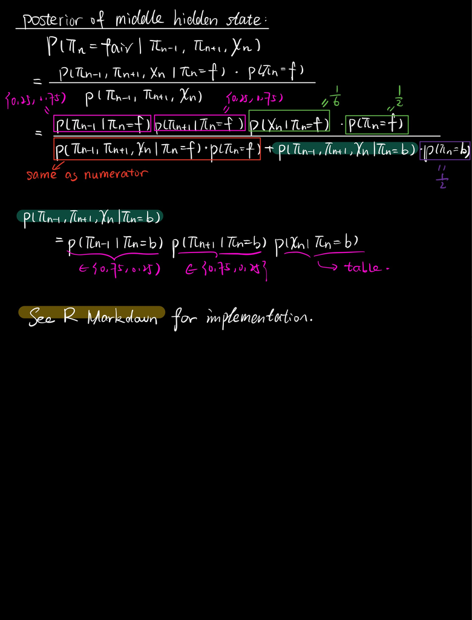

### Question 2 part (a) second part

##### **Implementation of getting the posterior of middle hidden states**

```r
xn = c(4, 4, 5, 2, 2, 4, 6, 6, 1, 4, 1, 1, 3, 5, 5, 2, 5, 4, 2, 1)
p_bias = c(2/13, 2/13, 1/13, 4/13, 2/13, 2/13)
len = length(xn)
post = rep(NA, 0)
```

```r
for (i in seq(2, 19, 1)) {
  x = xn[i]
  ##\pi_{n-1} = fair, \pi_{n+1} = fair
  ff = (0.75*0.75*(1/6)*0.5)/((0.75*0.75*(1/6)*0.5) + (0.25 * 0.25 * p_bias[x] * 0.5))
  post = append(post, ff)

  ##\pi_{n-1} = fair, \pi_{n+1} = bias
  fb = (0.75*0.25*(1/6)*0.5)/((0.75*0.25*(1/6)*0.5) + (0.75 * 0.25 * p_bias[x] * 0.5))
  post = append(post, fb)

  ##\pi_{n-1} = bias, \pi_{n+1} = fair
  bf = (0.25*0.75*(1/6)*0.5)/((0.25*0.75*(1/6)*0.5) + (0.25 * 0.75 * p_bias[x] * 0.5))
  post = append(post, bf)

   ##\pi_{n-1} = bias, \pi_{n+1} = bias
  bb = (0.25*0.25*(1/6)*0.5)/((0.25*0.25*(1/6)*0.5) + (0.75 * 0.75 * p_bias[x] * 0.5))
  post = append(post, bb)
}
```

```r
tab <- matrix(round(post,3), ncol = 4, byrow = TRUE)
colnames(tab) <- c("pi(n-1)=pi(n+1)=fair","pi(n-1)=fair,pi(n+1)=bias","pi(n-1)=bias,pi(n+1)=fair", "pi(n-1)=pi(n+1)=bias")
rownames(tab) <- c(2:(len-1))
tab <- as.table(tab)
formattable(tab)
```

```
##    pi(n-1)=pi(n+1)=fair pi(n-1)=fair,pi(n+1)=bias pi(n-1)=bias,pi(n+1)=fair
## 2  0.830                0.351                     0.351
## 3  0.907                0.520                     0.520
## 4  0.907                0.520                     0.520
## 5  0.907                0.520                     0.520
## 6  0.830                0.351                     0.351
## 7  0.907                0.520                     0.520
## 8  0.907                0.520                     0.520
## 9  0.907                0.520                     0.520
## 10 0.830                0.351                     0.351
## 11 0.907                0.520                     0.520
## 12 0.907                0.520                     0.520
## 13 0.951                0.684                     0.684
## 14 0.907                0.520                     0.520
## 15 0.907                0.520                     0.520
```

[output cut: 23 more lines]

### Question 2 part(b) Gibbs Sampling

```r
set.seed(1009)
pdist <- function(p){return(runif(1)<p)}
initial <- rep(TRUE, 20)
pi <- c()
cumm <- data.frame()[1:20,]
```

```r
##gibbs sampling

for (i in seq(1, 10000, 1)){

  if (initial[2] == TRUE){
    pi[1] = pdist(0.619)
  }else{
    pi[1] = pdist(0.152)
  }

  if(initial[19] == TRUE){
    pi[20] = pdist(0.765)
  }else{
    pi[20] = pdist(0.265)
  }

  for (j in seq(2, 19, 1)) {
    if (initial[j - 1] == TRUE & initial[j + 1] == TRUE) {
      pi[j] = pdist(tab[j-1, 1])
    } else if (initial[j - 1] != initial[j + 1]){
      pi[j] = pdist(tab[j-1, 2])
    } else{
      pi[j] = pdist(tab[j-1, 4])
    }
  }
  initial = pi
  cumm[i] = pi
}
```

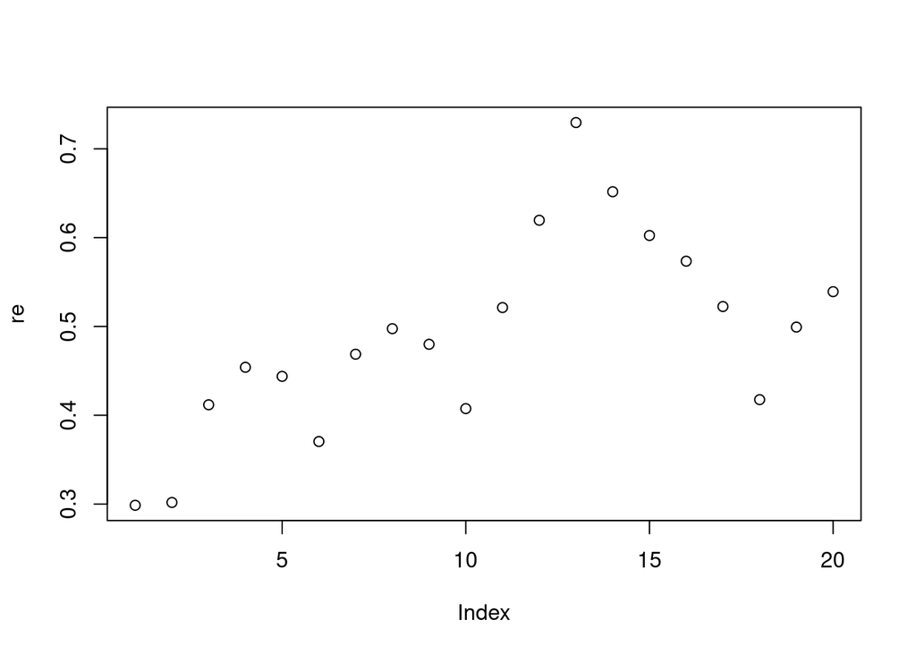

```r
re <- rowSums(cumm[, -500])/9500
plot(re)
```

### Question 3 part a

```r
set.seed(1009)
### import data
gradAdmit = read.csv('gradAdmit.csv')
n = nrow(gradAdmit) # number of samples
# hold out 20% for testing
sample = sample.int(n = n, size = floor(.2*n), replace = F)
train = gradAdmit[-sample,]
test = gradAdmit[sample,]
### there are 80 obs in test, and 320 obs in train.
table(train$admit)
```

```
##
##   0   1
## 222  98
```

```r
table(test$admit)
```

```
##
##  0  1
## 51 29
```

```r
admit_train = sum(train$admit)/nrow(train)
admit_test = sum(test$admit)/nrow(test)
```

In the training set, there are 98 students got admitted out of 320 students. Therefore, 30.62% got admitted in the training set, and 69.38% didn’t got admitted.

In the testing set, there are 29 students got admitted out of 80 students. Therefore, 36.25% got admitted in the training set, and 63.75% didn’t got admitted.

### Question 3 part b

```r
svm = svm(formula =  factor(admit) ~ .,
                  kernel = "radial",
                  cost = 9,
                  gamma = 0.16,
                  data = train)

pred = predict(svm, newdata = test, type='response')

table(factor(test$admit), pred)
```

```
##    pred
##      0  1
##   0 48  3
##   1 21  8
```

```r
precision = 8/(8+3)
recall = 8/(8+21)
spec = 48/(48+3)
```

Precision in this case is 0.7272727. Recall in this case is 0.2758621. Specificity in this case is 0.9411765.

### Question 3 part c

In the training set, there are 98 students got admitted and 222 students got rejected. We need to generate 124 more samples to get class balance.

```r
train$admit <- factor(train$admit)
newData = SMOTE(admit~., train, perc.over=124, perc.under=0)

# combine with original training set
newTrain <- train[train$admit==0,]
newTrain <- rbind(newTrain, newData)
table(newTrain$admit)
```

```
##
##   0   1
## 222 196
```

After applying the SMOTE function, the new balance is about correct.

### Question 3 part d

```r
svmModel = svm(formula =  factor(admit) ~ .,
                  kernel = "radial",
                  cost = 9,
                  gamma = 0.16,
                  data = newTrain)

pred = predict(svmModel, newdata = test, type='response')

table(factor(test$admit), pred)
```

```
##    pred
##      0  1
##   0 27 24
##   1 14 15
```

The new precision is 0.3846154, the new recall is 0.5172414, the new specificity is 0.5294118.

Comparing to the result without SMOTE, we see that precision dropped, recall increased, and specificity dropped.

Although precision and specificity dropped, we have great improvement in recall.

### Question 4 part a

This is a special case of $\lambda = 1$ of question 2 from assignment 1.

```r
## lambda = 1
set.seed(1009)
lambda = 1
n = 10^8
x = runif(n,0,1)
y = -ln(x)
y10pi = length(y[y>=(10*pi)])
percy10pi = y10pi/n
#result_1 = sum(g)/n
# result_1_compare = 1 / (1+lambda^2)
```

### Question 4 Part b

```r
realResult = 1 / (1+lambda^2)
```

From Assignment2 Question2 part b, we knew that

$$\int_0^{\infty}e^{-x}sin\left(x\right)dx = \frac{1}{2}$$
Also,

$$\int_0^{10\pi}e^{-x}sin\left(x\right)dx = -\frac{1}{2e^{10\pi }}+\frac{1}{2}$$
Hence, the desired integral is
$$\int_{10\pi}^{\infty}e^{-x}sin\left(x\right)dx = \frac{1}{2e^{10\pi }}$$
### Question 4 Part c

We want to find a $p^*(x)$ larger than $p(x)$ when $x\geq10\pi$ and equals $0$ when $x<10\pi$.

### Question 4 Part d

```r
sample <- rexp(10^6, 1)

sum <- 0
for(i in sample){
    sum <- sum + sin(i) * exp(-10*pi)
}

estimate <- sum/10^6
estimate
```

[output not shown]

The estimate is very close to the real value.